# Análisis exploratorio de árboles

En este reporte hacemos una descripción de los datos de un censo de árboles en conglomerados de Aguascalientes, Colima, Nayarit y Jalisco.

### Descripción y limpieza de datos

Contamos con 4 bases de datos, las mediciones a nivel árbol están en la base de datos **arbolado**, las bases restantes cuentan con información de los conglomerados:

```r
arbolado <- tbl_df(read.csv("datos/arbolado.csv"))
conglomerado_bq <- tbl_df(read.csv("datos/conglomerado_bq.csv"))
conglomerado <- tbl_df(read.csv("datos/conglomerados.csv"))
selva <- tbl_df(read.csv("datos/selva.csv"))

arbolado
```

```
## Source: local data frame [14,947 x 29]
##
##    IdConglomerado Anio  Estado Municipio Formato Tipo_cgl
## 1           51249 2013 Nayarit      Jala  Bosque  Inicial
## 2           51249 2013 Nayarit      Jala  Bosque  Inicial
## 3           51249 2013 Nayarit      Jala  Bosque  Inicial
## 4           51249 2013 Nayarit      Jala  Bosque  Inicial
## 5           51249 2013 Nayarit      Jala  Bosque  Inicial
## 6           51249 2013 Nayarit      Jala  Bosque  Inicial
## 7           51249 2013 Nayarit      Jala  Bosque  Inicial
## 8           51249 2013 Nayarit      Jala  Bosque  Inicial
## 9           51249 2013 Nayarit      Jala  Bosque  Inicial
## 10          51249 2013 Nayarit      Jala  Bosque  Inicial
## ..            ...  ...     ...       ...     ...      ...
## Variables not shown: Veg_prim_levantada (fctr), Veg_sec_levantada (fctr),
##   Veg_prim_esperada (fctr), Veg_sec_esperada (fctr), Latitud (fctr),
##   Longitud (fctr), X (dbl), Y (dbl), Altitud (int), Sitio (int), Registro
##   (int), Arbol (int), Genero_Especie (fctr), forma_biologica (fctr),
##   Condicion (fctr), NomComun (fctr), DiametroNormal (dbl), AlturaTotal
##   (dbl), DiametroCopa (dbl), AlturaFusteLimpio (dbl), AlturaComercial
##   (dbl), Distancia (dbl), Azimut (int)
```

```r
conglomerado_bq
```

```
## Source: local data frame [118 x 42]
##
##    IdConglomerado Anio  Estado           Municipio Formato
## 1           43810 2013 Nayarit           Huajicori  Bosque
## 2           43815 2013 Nayarit           Huajicori  Bosque
## 3           44144 2013 Nayarit           Huajicori  Bosque
## 4           44316 2013 Nayarit           Huajicori  Bosque
## 5           44502 2013 Jalisco Huejuquilla el Alto  Bosque
## 6           44667 2013 Jalisco Huejuquilla el Alto  Bosque
## 7           44964 2013 Nayarit           Acaponeta  Bosque
## 8           45285 2013 Nayarit           Acaponeta  Bosque
## 9           45443 2013 Nayarit           Acaponeta  Bosque
## 10          45794 2013 Jalisco           Mezquitic  Bosque
## ..            ...  ...     ...                 ...     ...
## Variables not shown: Veg_prim_levantada (fctr), Veg_sec_levanatda (fctr),
##   Veg_prim_esperada (fctr), Veg_sec_esperada (fctr), Tipo_cgl (fctr),
##   Monitoreo (fctr), Muestreado (fctr), Cubierta_Vegetal (fctr), Tenencia
##   (fctr), Cuenca (fctr), Subcuenca (fctr), Sitios_x_cgl (int), Sitio_1
##   (int), Sitio_2 (int), Sitio_3 (int), Sitio_4 (int), Arboles_x_cgl
##   (fctr), Latitud (fctr), Longitud (fctr), X (dbl), Y (dbl), Altitud
##   (int), Fisiografia (fctr), Pendiente (int), Uso_suelo_SCV (fctr),
##   con_Cuerpos_agua (int), con_Diversidad (int), con_epifitas (int),
##   con_flora_riego (int), con_Impactos_amb (int), con_Incendios (int),
##   con_Plagas (int), Punto_control (int), con_suelos (int), con_Sitios
##   (int), Descripcion (fctr), Observaciones (fctr)
```

[output not shown]

Veamos cómo se distribuyen los conglomerados de acuerdo al tipo de vegetación primaria,

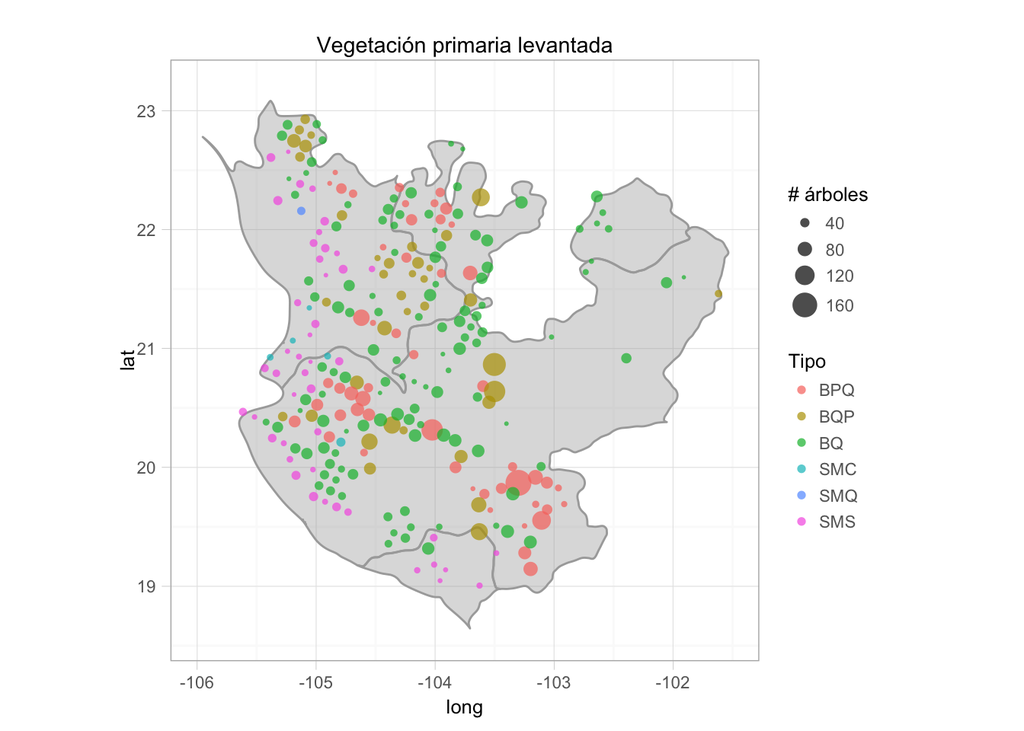

```r
bases <- list(conglomerado, conglomerado_bq, selva)
names(bases) <- c("bpq_bqp", "bq", "selva")
congs <- ldply(bases, rbind)
rm(conglomerado, conglomerado_bq, selva)

ggplot(data = congs) +
  geom_polygon(data = edo_df, colour='darkgray', fill = "darkgray", alpha = 0.4,
               aes(x = long, y = lat, group = group)) +
  geom_point(aes(x = X, y = Y, color = Veg_prim_levantada,
                 size = Arboles_x_cgl), alpha = 0.7) +
  # facet_wrap(~.id) +
  coord_fixed() +
  xlim(-106, -101.5) +
  ylim(18.6, 23.2) +
  labs(title = "Vegetación primaria levantada", color = "Tipo",
       size = "# árboles")
```

Antes de proseguir realizamos algunas recodificaciones:

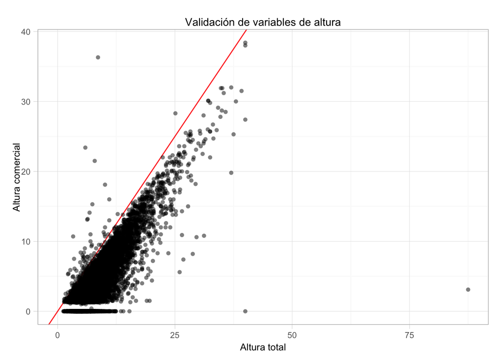

```r
arbolado_tidy <- arbolado %>%
  mutate(diametro_normal = mapvalues(DiametroNormal, 999, NA),
         diametro_copa = mapvalues(DiametroCopa, -9999, NA),
         altura_comercial = mapvalues(AlturaComercial, -9999, NA))

ggplot(arbolado_tidy, aes(x = AlturaTotal, y = altura_comercial)) +
  geom_abline(color = "red", alpha = 0.9) +
  geom_point(alpha = 0.5) +
  labs(title = "Validación de variables de altura",
       x = "Altura total", y = "Altura comercial")
```

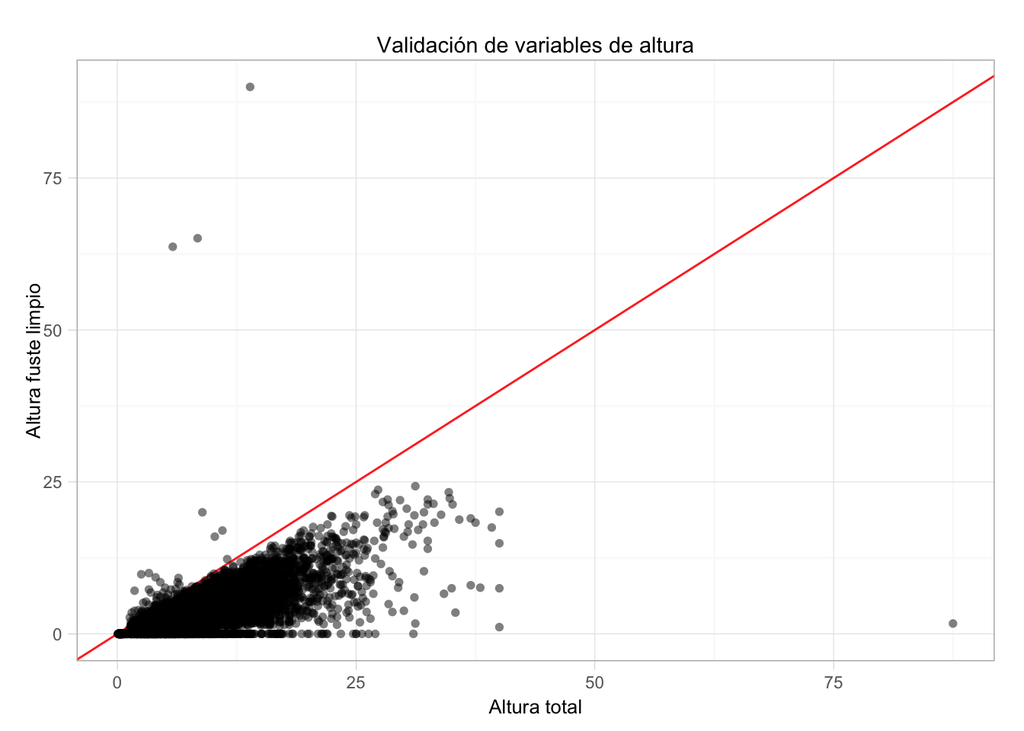

```r
ggplot(arbolado_tidy, aes(x = AlturaTotal, y = AlturaFusteLimpio)) +
  geom_abline(color = "red", alpha = 0.9) +
  geom_point(alpha = 0.5) +
  labs(title = "Validación de variables de altura",
       x = "Altura total", y = "Altura fuste limpio")
```

Suponemos que la altura comercial no puede ser mayor que la altura total, con el criterio de mantener la altura total. Lo mismo para altura fuste limpio.

```r
# altura comercial
cambiar <- arbolado_tidy$altura_comercial > arbolado_tidy$AlturaTotal
cambiar[is.na(cambiar)] <- FALSE
arbolado_tidy$altura_comercial[cambiar] <- arbolado_tidy$AlturaTotal[cambiar]

# quitar valor atípico
arbolado_tidy$AlturaTotal[arbolado_tidy$AlturaTotal > 75] <- NA

# altura fuste limpio
cambiar <- arbolado_tidy$AlturaFusteLimpio > arbolado_tidy$AlturaTotal
cambiar[is.na(cambiar)] <- FALSE
arbolado_tidy$AlturaFusteLimpio[cambiar] <- arbolado_tidy$AlturaTotal[cambiar]
```